# IIT-Leiden dictator manipulation

## General sample characteristics

The dataset contains 73 subjects. There are 35 subjects in condition *one-step dictator* and 38 subjects in condition *two-step dictator*.

## Likeability of robots

We would expect to find an effect of robot type on likeability. We would **not** expect to find an effect of condition on likeability, as our conditions merely reflect dictator game type.

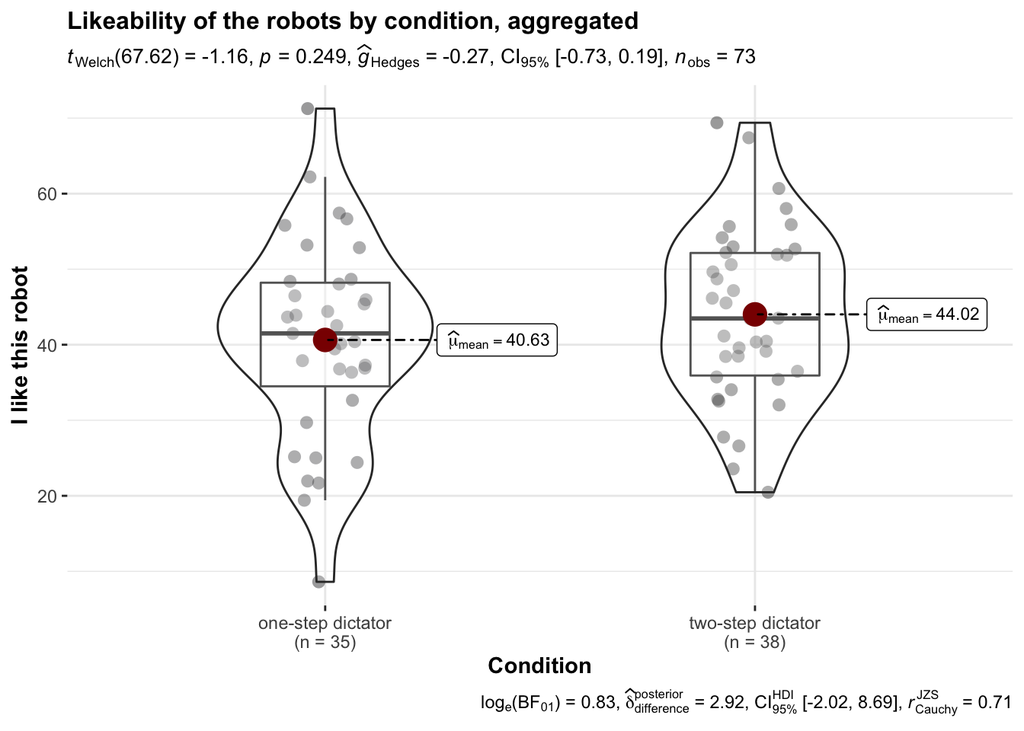

Bayes factor in favor of an effect of robot type on likeability is BF<sub>10</sub> = 2.2479734 × 10<sup>126</sup>. This is **decisive** evidence in favor of an effect.

Bayes factor in favor of an effect of condition on likeability is BF<sub>10</sub> = 0.201. This is **substantial** evidence against an effect.

## Dictator game behavior

### One-step vs. two-step dictator games

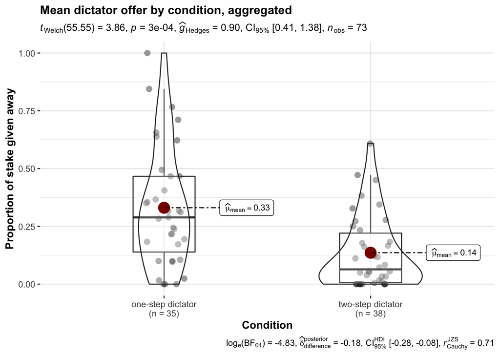

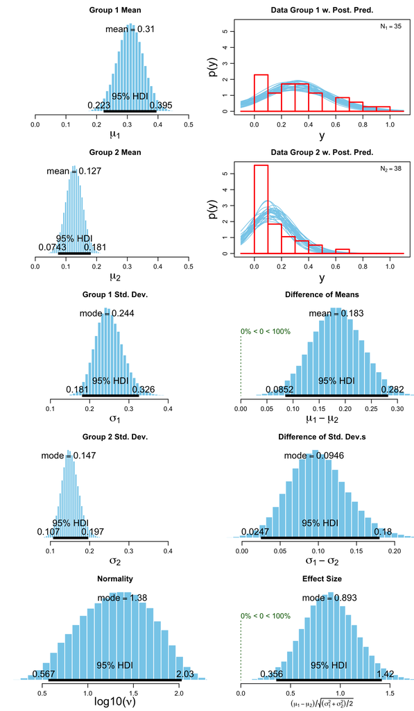

Bayes factor in favor of an effect of condition on dictator game behavior is BF<sub>10</sub> = 121.737. This is **decisive** evidence in favor of an effect.

Bayes factor in favor of an effect of robot type on dictator game behavior is BF<sub>10</sub> = 2.2001314 × 10<sup>29</sup>. This is **decisive** evidence in favor of an effect.

### Hypothetical offers vs. real money

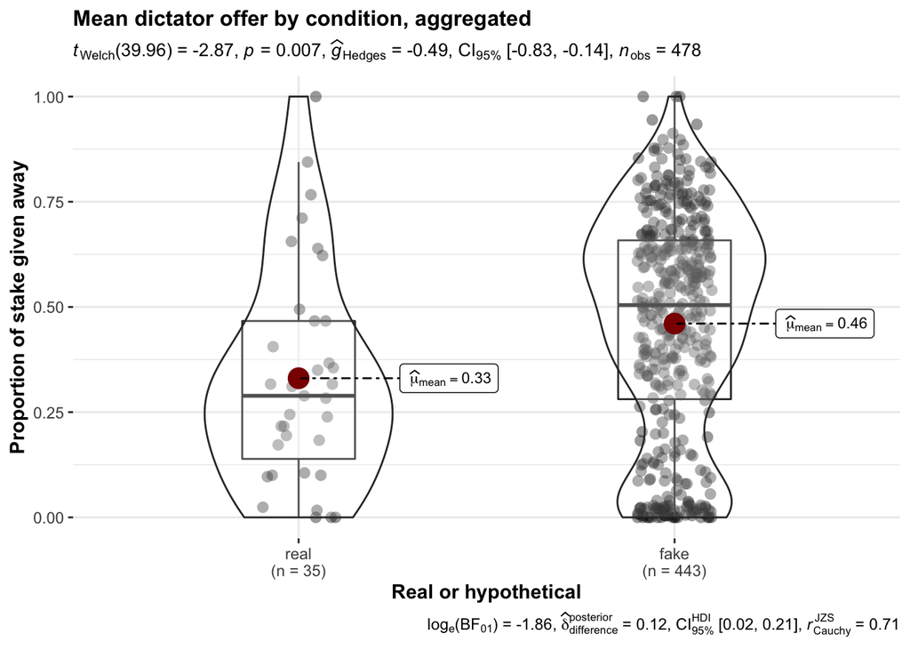

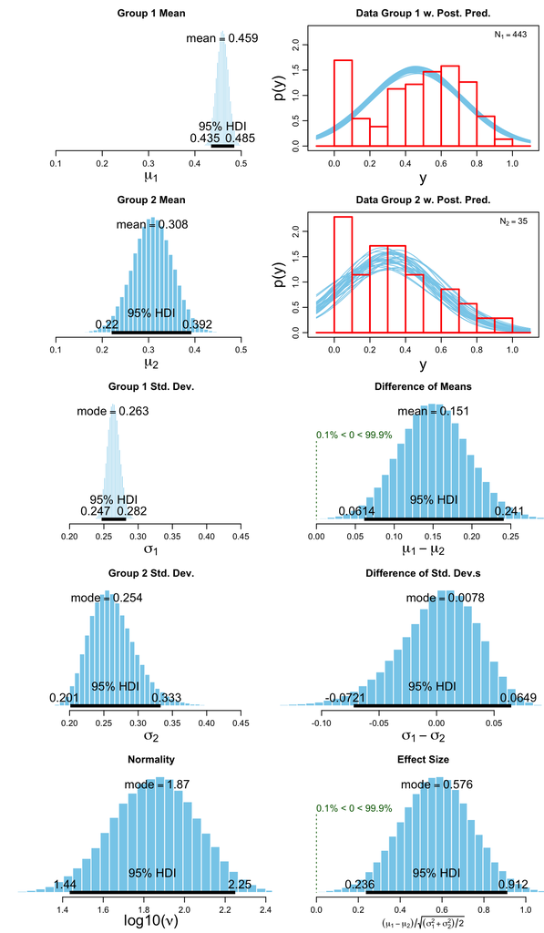

Bayes factor in favor of an effect of real/hypothetical money on dictator game behavior is BF<sub>10</sub> = 7.006. This is **substantial** evidence in favor of an effect.